# An analysis of out of school rate for children one year younger than the official entry age across the world

Wanjiku Kihato

2023-04-29

# Introduction

Education is an important aspect of the growth of any nation, hence children who are not in school pose a risk to the growth and development of a nation. This document explores the out of school rate for children one year younger than official entry age as gathered by UNICEF which refers to the total number of children who are one year younger than the official age of primary education and who are not enrolled in pre-primary or primary education.

We begin by cleaning the data then proceed to answering key questions through the use of a

1. Bar graph
2. Scatter plot
3. Time series chart
4. World map

## Reading the csv file and checking the structure of the datatset

#### Reading the file

```r
unicef.dataset <- read.csv("C:/Users/Jenom/OneDrive/Documents/Novus/Assignments/BDA/unicef_indicator_1.csv")
```

#### Checking the structure of the dataset

```r
summary(unicef.dataset)
```

```
##    country          alpha_2_code       alpha_3_code        numeric_code
##  Length:529         Length:529         Length:529         Min.   :  8.0
##  Class :character   Class :character   Class :character   1st Qu.:208.0
##  Mode  :character   Mode  :character   Mode  :character   Median :438.0
##                                                           Mean   :434.1
##                                                           3rd Qu.:662.0
##                                                           Max.   :887.0
##   indicator          time_period     obs_value          sex
##  Length:529         Min.   :2014   Min.   : 0.000   Length:529
##  Class :character   1st Qu.:2019   1st Qu.: 3.283   Class :character
##  Mode  :character   Median :2019   Median :11.908   Mode  :character
##                     Mean   :2019   Mean   :23.135
##                     3rd Qu.:2020   3rd Qu.:36.659
##                     Max.   :2022   Max.   :96.084
##  unit_multiplier unit_of_measure    observation_status
##  Mode:logical    Length:529         Mode:logical
##  NA's:529        Class :character   NA's:529
##                  Mode  :character
##
##
##
##  observation_confidentaility
##  Mode:logical
##  NA's:529
##
##
##
##
##  time_period_activity_related_to_when_the_data_are_collected current_age
##  Mode:logical                                                Length:529
##  NA's:529                                                    Class :character
##                                                              Mode  :character
##
##
##
```

```r
str(unicef.dataset)
```

```
## 'data.frame':    529 obs. of  14 variables:
##  $ country                                                    : chr  "Albania" "Albania" "Albania" "Angola" ...
##  $ alpha_2_code                                               : chr  "AL" "AL" "AL" "AO" ...
##  $ alpha_3_code                                               : chr  "ALB" "ALB" "ALB" "AGO" ...
##  $ numeric_code                                               : int  8 8 8 24 24 24 660 660 660 28 ...
##  $ indicator                                                  : chr  "Out-of-school rate for children one year younger than official entry age (administrative data)" "Out-of-school rate for children one year younger than official entry age (administrative data)" "Out-of-school rate for children o…
##  $ time_period                                                : int  2018 2018 2018 2016 2016 2016 2019 2019 2019 2018 ...
##  $ obs_value                                                  : num  1.85 3.9 2.93 38.52 31.18 ...
##  $ sex                                                        : chr  "Female" "Male" "Total" "Female" ...
##  $ unit_multiplier                                            : logi  NA NA NA NA NA NA ...
##  $ unit_of_measure                                            : chr  "%" "%" "%" "%" ...
##  $ observation_status                                         : logi  NA NA NA NA NA NA ...
##  $ observation_confidentaility                                : logi  NA NA NA NA NA NA ...
##  $ time_period_activity_related_to_when_the_data_are_collected: logi  NA NA NA NA NA NA ...
##  $ current_age                                                : chr  "Total" "Total" "Total" "Total" ...
```

# Data Cleaning

#### Removing empty columns

On exploration of the dataset, we observed that about 5 columns had NA values, so removing them was the best course of action

```r
clean.unicef <- select(unicef.dataset, -9:-14)
```

#### Keeping only the ‘Male’ and ‘Female’ value in the sex column

The sex column contained three distinct values, namely 1. Male 2. Female 3. Total For the first few graphs we only needed to display the distribution between male and female, so we created a subset of the dataset that only contained those fields

```r
valid_sex <- c('Male', 'Female')
clean.unicef <- clean.unicef %>%
  filter(sex %in% valid_sex)
```

# Exploratory Data Analysis

## 1. Total observed values per year

We begin by taking a birds eye view to understand this trend on a global scale.

```r
total_obs_val_per_year <- clean.unicef %>%
  select(time_period, sex, obs_value) %>%
  group_by(time_period, sex) %>%
  summarise(obs_value = sum(obs_value)) %>%
  arrange(desc(time_period))
```

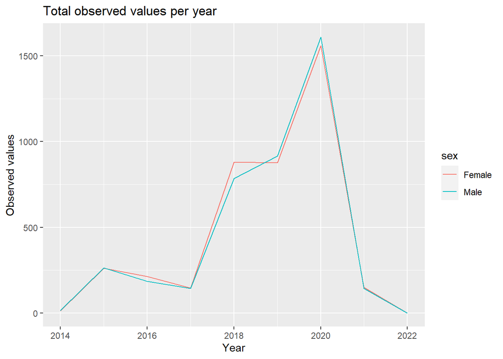

```r
ggplot(data = total_obs_val_per_year, aes(x=time_period, y=obs_value)) + geom_line(aes(colour=sex)) + labs(title ="Total observed values per year", x = "Year", y = "Observed values")
```

From this graph we noticed a rise from 2014 to 2020, after which we saw a significant drop in the numbers from 2020 to 2022. This could be as a result of a number of things, notably due to the impact of COVID-19 on children’s education awareness.

## 2. The ratio of Male to Female in top 15 countries with highest observed values

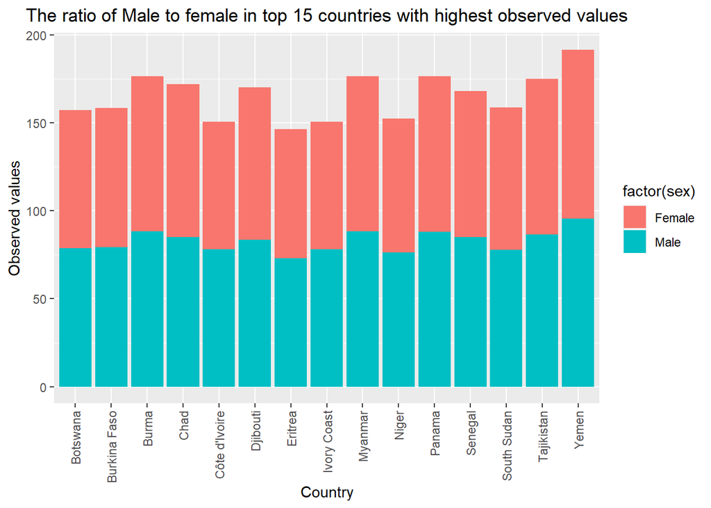

```r
highest_male_to_female <- clean.unicef %>% select(country, sex, obs_value) %>% arrange(desc(obs_value)) %>% head(30)

highest_male_to_female <- highest_male_to_female %>% arrange(country, obs_value)

ggplot(highest_male_to_female, aes(country, obs_value, fill = factor(sex))) + labs(title ="The ratio of Male to female in top 15 countries with highest observed values", x = "Country", y = "Observed values") + theme(plot.title = element_text(hjust = 0.5)) + theme(axis.text.x = element_text(angle = 90, vjust = 0.5, hjust=1)) + geom_col()
```

## 3. The total observed values across the world

Understanding how these figures are distributed across the world can help provide insights into assisting with providing solutions on a country level, continent level or on a global scale.

##### First we have to load in the world map

```r
world_map <- map_data("world")
```

We want to plot the total number so we have to subbset the original dataset to keep only the total in the sex column

```r
unicef_for_map <- unicef.dataset
total_sex <- c('Total')
unicef_for_map <- unicef_for_map %>% filter(sex %in% total_sex)
```

##### Removing empty columns

```r
unicef_for_map <- select(unicef_for_map, -9:-14)
```

Then we have to rename the country column of our dataset to “region”, so as to allow us perform a group by when joining both datasets

```r
colnames(unicef_for_map)[colnames(unicef_for_map) == 'country'] <- 'region'
```

##### Only keeping region and obs_val colum

```r
unicef_for_map = subset(unicef_for_map, select = c('region', 'obs_value'))
```

Then we join both datasets on the region column

```r
world_map = left_join(world_map, unicef_for_map, by="region")
```

Joining them lead to most rows in the obs_value columns having NA values so we created a new dataframe to keep only the rows with values in the obs_value column

```r
world_map_for_plotting <- world_map %>% filter(!is.na(world_map$obs_value))
```

##### Plotting the map

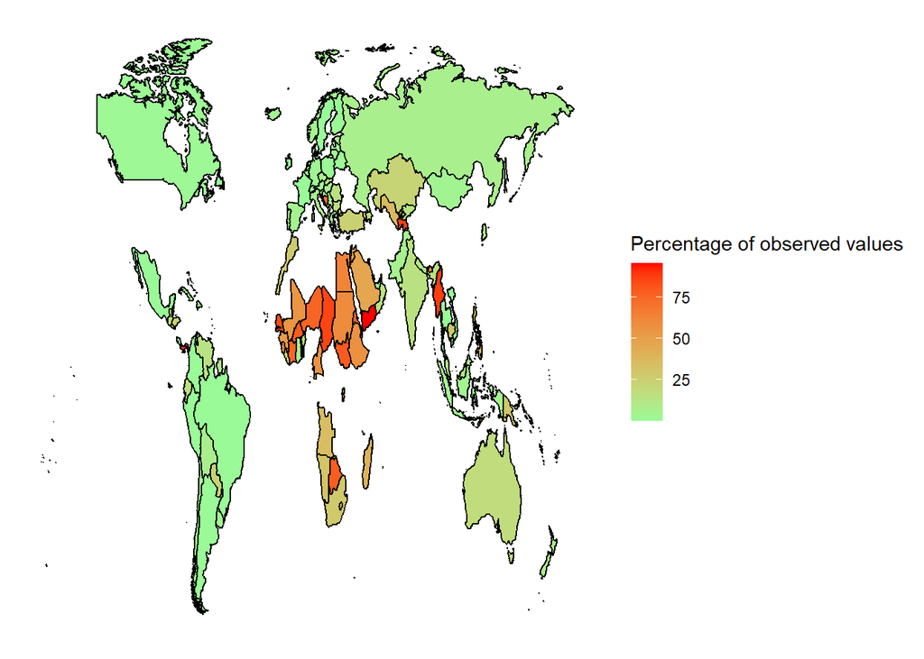

```r
map1 <- ggplot(world_map_for_plotting, aes(x = long, y = lat, group = group)) +
  geom_polygon(aes(fill = obs_value), color = "black")

map2 <- map1 + scale_fill_gradient(name = "Percentage of observed values", low = "palegreen", high = "red", na.value = "grey-50") +
  theme(axis.text.x = element_blank(),
        axis.text.y = element_blank(),
        axis.ticks = element_blank(),
        axis.title.y = element_blank(),
        axis.title.x = element_blank(),
        rect = element_blank())
map2
```

The map shows the total observed values across the world and shows regions it is lowest in in green and highest in red. We notice that certain regions had high observed values while most regions had low observed values, which means if a solution was to be proffered, it might be on a regional level.

## 4. Scatter plot with Regression line

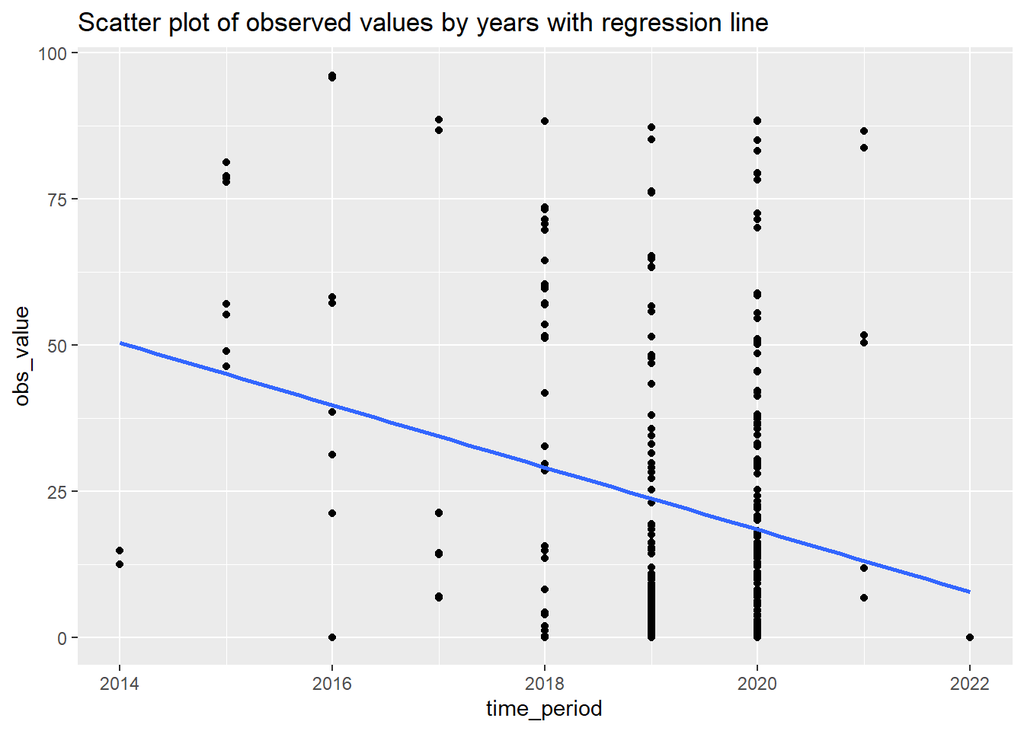

```r
ggplot(data = clean.unicef, aes(x = time_period, y = obs_value)) +
  geom_point(color='black') +
  geom_smooth(method = "lm", se = FALSE) +
  labs(title ="Scatter plot of observed values by years with regression line")
```

From the regression line, we notice a steady decrease in the numbers wghich signifies an improvement in the observed values over the years